# Risk Analyses and Prediction of US Adult Chronic Diseases

# 6. Trainining Models for Prediction

## 6.1. Full Prediction Model Training

All predictors are included in the estimation of the prediction models for the 16 diseases. Records with missing values are excluded in the model training process. About 7.6% of records been removed because of missing values.

The current directory is specified for my computer, please change the folder name you want to use, or delete the directory to use your default workspace for saving and reading the temporary results.

Please be patient, the training may take several minutes or longer depending on the environment it runs.

### 6.1.1. Estimation and Cross-Validation

```r
j=1
pred.y.logit <- NA
obs.y.logit <- NA
pred.y.rf <- NA
obs.y.rf <- NA
for (j in 1:16) {
  # j is the jth diseases such as dis1, dis2,...dis29, dis99
  Y=YY[,j]
  YXX <- data.frame(Y, XX)
  YXX <- YXX[complete.cases(YXX),]
  #dim(data.frame(Y, XX))
  dim(YXX)
  Xmat <- data.frame(model.matrix(~., data = YXX[, c(2:ncol(YXX))] ))
  dt <-  data.frame(y=YXX[,"Y"],Xmat)
  ###logistic CV with all variables
  dtxx <- dt
  N = nrow(dtxx)
  K = 10
  set.seed(1234)
  # randomly select one of the K from N, the number of rows of data
  s = sample(1:K, size = N, replace = T) # used for label rows of data titanic for each group
  pred.outputs.logit <- vector(mode = "numeric", length = N)
  obs.outputs.logit <- vector(mode = "numeric", length = N)
  offset <- 0 # offset is a pointer used for determine where to pending results for the next loop

  i=1
  for(i in 1:K){
        train <- filter(dtxx, s != i)
        test <- filter(dtxx, s == i)
        obs.outputs.logit[1:length(s[s == i]) + offset] <- test$y

      dt.glm <- glm(y ~ . , data =train, family = binomial(logit))
      logit.pred.curr <- predict(dt.glm, test, type = "response")
      pred.outputs.logit[1:length(s[s == i]) + offset] <- logit.pred.curr
        offset <- offset + length(s[s == i])
     #  return(list(obs.outputs.logit, pred.outputs.logit))
    }
  pred.y.logit[j] <- list(pred.outputs.logit)
  obs.y.logit[j] <- list(obs.outputs.logit)
###random forest with top variables
dtxx <- dt
  N = nrow(dtxx)
  K = 10
  set.seed(1234)
  # randomly select one of the K for N times, the number of rows of data
  s = sample(1:K, size = N, replace = T) # used for label rows of data titanic for each group
  pred.outputs.rf <- vector(mode = "numeric", length = N) # to store prediction
  obs.outputs.rf <- vector(mode = "numeric", length = N) # to store response yi
  offset <- 0
  i=1
  for(i in 1:K){
    train <- filter(dtxx, s != i)
    test <- filter(dtxx, s == i)
    obs.outputs.rf[1:length(s[s == i]) + offset] <- test$y

    #RF train/test
    rf <- randomForest(y ~ ., data = train, ntree = 100)

    rf.pred.curr <- predict(rf, newdata = test, type = "prob")
    pred.outputs.rf[1:length(s[s == i]) + offset] <- rf.pred.curr[ , 2]

      # offset is used for determine where to pending results for the next loop
    offset <- offset + length(s[s == i])
#   return (obs.outputs.rf)
  }
  pred.y.rf[j] <- list(pred.outputs.rf)
  obs.y.rf[j] <- list(obs.outputs.rf)
}
Xmat <- X <- NULL
Y <- YXX <-  NULL
# saveRDS(pred.y.logit,file="pred_y_logit.rds")
# saveRDS(obs.y.logit, file="obs_y_logit.rds")
# saveRDS(pred.y.rf, file="pred_y_rf.rds")
# saveRDS(obs.y.rf, file="obs_y_rf.rds")
```

### 6.1.2. Full Model AUC and ROC

```r
#getwd()
#please change the directory or delete the directory for reading the files from the above code
# pred.y.logit <- readRDS("/home/Nianfu/pred_y_logit.rds")
# obs.y.logit <- readRDS("/home/Nianfu/obs_y_logit.rds")
# pred.y.rf <- readRDS("/home/Nianfu/pred_y_rf.rds")
# obs.y.rf <- readRDS("/home/Nianfu/obs_y_rf.rds")
# AUC in one table
auc <- matrix(data=NA, nrow = 16, ncol=2)
i=1
for (i in c(1:16)){
  r1 <- roc(obs.y.logit[[i]], pred.y.logit[[i]], ci = TRUE)
  auc[i,1] = r1$auc[1]
  r2 <- roc(obs.y.rf[[i]], pred.y.rf[[i]], ci = TRUE)
  auc[i,2] = r2$auc[1]
}
aucdt <- as.data.frame(auc)
names(aucdt) = c("Logistic", "Random.Forest")
aucdt
```

```
##     Logistic Random.Forest
## 1  0.7635645     0.6688169
## 2  0.8001406     0.6852917
## 3  0.8071521     0.7785407
## 4  0.7027323     0.6573806
## 5  0.8306800     0.7490486
## 6  0.8238273     0.6438401
## 7  0.8389730     0.7327150
## 8  0.8428873     0.7584932
## 9  0.8192221     0.7522376
## 10 0.7708274     0.6042725
## 11 0.8434906     0.7218380
## 12 0.8626201     0.8024144
## 13 0.7465415     0.6272773
## 14 0.6220787     0.4728464
## 15 0.6456473     0.4966196
## 16 0.6876770     0.6265241
```

```r
print(paste("logistic 10-fold CV model AUC = ", round(mean(auc[,1]), 3)))
```

```
## [1] "logistic 10-fold CV model AUC =  0.776"
```

```r
print(paste("Random Forest 10-fold CV model AUC = ", round(mean(auc[,2]), 3)))
```

```
## [1] "Random Forest 10-fold CV model AUC =  0.674"
```

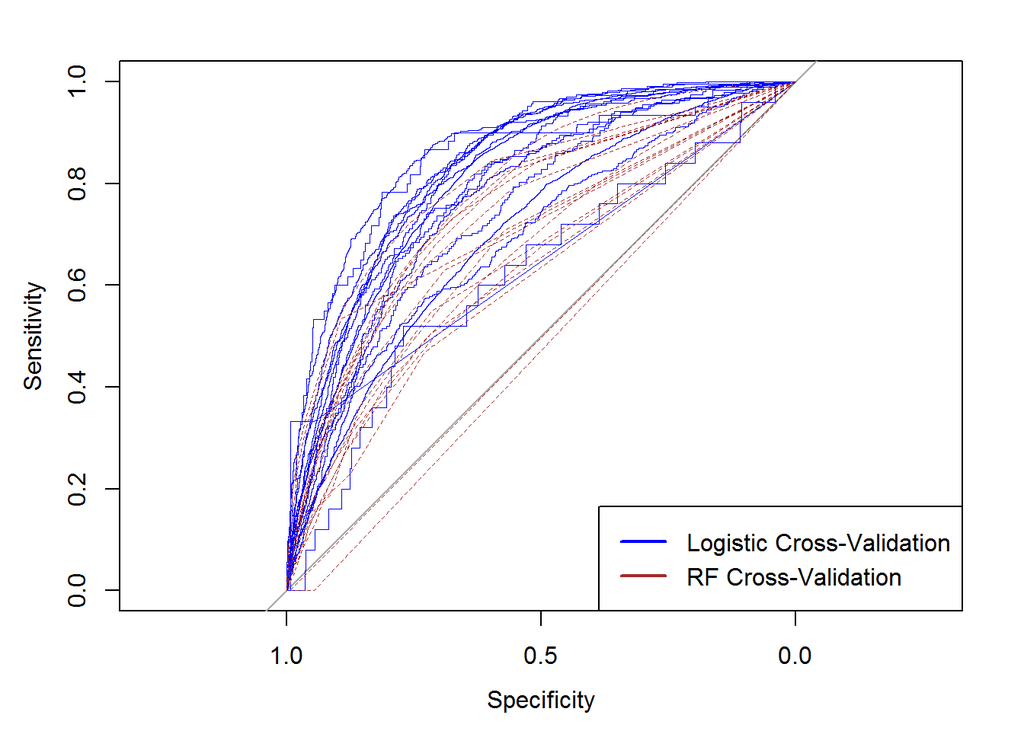

```r
#Plot ROCs
par(mfrow = c(1,1))
i=1
plot.roc(obs.y.logit[[1]], pred.y.logit[[1]],  lwd = 0.7, lty=1, ci = TRUE, col = "blue") #CV of svm
plot.roc(obs.y.rf[[i]], pred.y.rf[[i]],  lwd = 0.7, lty=2, ci = TRUE, col = "brown", add = TRUE) #CV of rf
legend("bottomright", legend = c("Logistic Cross-Validation", "RF Cross-Validation"), col = c("blue", "brown"), lwd = 2, lty = c(1,1,2,1))
for (i in c(2:16)){
plot.roc(obs.y.logit[[i]], pred.y.logit[[i]], lwd = 0.7, ci = TRUE, lty=1, col = "blue", add=TRUE) #CV of svm
plot.roc(obs.y.rf[[i]], pred.y.rf[[i]], lwd = 0.7, ci = TRUE, lty=2, col = "brown", add = TRUE) #CV of rf
}
```

> The logit models predict better than random forest models

## 6.2. Reduced Models for Prediction

In this section, the top 10 variables/categories from the full models are used for the model training with 10-fold cross-validation. AUC and ROC are produced to compare the power of predictions.

### 6.2.1. Reduced Model Cross-Validation

```r
j=1
pred.y.logit10 <- NA
obs.y.logit10 <- NA
pred.y.rf10 <- NA
obs.y.rf10 <- NA
for (j in 1:16) {
  # j is the jth diseases such as dis1, dis2,...dis29, dis99
  Y=YY[,j]
  YXX <- data.frame(Y, XX)
  YXX <- YXX[complete.cases(YXX),]
  Xmat <- data.frame(model.matrix(~., data = YXX[, c(2:ncol(YXX))]))
  # reduced 10 variables
  z <-  rownames(cefTab)[-1] # logistic coefficient from above code
  zp <- pvalTab[-1,j] #pvalue matrix from above code
  tp10nam <- z[order(zp)][1:10] # top 10 x
  tp10X <- Xmat[, tp10nam]
  Y10X <- data.frame(YXX$Y, tp10X)
  Xmat10 <- data.frame(model.matrix(~., data = Y10X[, c(2:ncol(Y10X))]))
  dt <-  data.frame(y=YXX[,"Y"],Xmat10)
  ###logistic CV with all variables
  dtxx <- dt
  N = nrow(dtxx)
  K = 10
  set.seed(1234)
  # randomly select one of the K from N, the number of rows of data
  s = sample(1:K, size = N, replace = T) # used for label rows for each group
  pred.outputs.logit <- vector(mode = "numeric", length = N)
  obs.outputs.logit <- vector(mode = "numeric", length = N)
  offset <- 0 # offset is a pointer used for determine where to pending results for the next loop

  i=1
  for(i in 1:K){
        train <- filter(dtxx, s != i)
        test <- filter(dtxx, s == i)
        obs.outputs.logit[1:length(s[s == i]) + offset] <- test$y

      dt.glm <- glm(y ~ . , data =train, family = binomial(logit))
      logit.pred.curr <- predict(dt.glm, test, type = "response")
      pred.outputs.logit[1:length(s[s == i]) + offset] <- logit.pred.curr
        offset <- offset + length(s[s == i])
     #  return(list(obs.outputs.logit, pred.outputs.logit))
    }
  pred.y.logit10[j] <- list(pred.outputs.logit)
  obs.y.logit10[j] <- list(obs.outputs.logit)
###random forest with top variables
dtxx <- dt
  N = nrow(dtxx)
  K = 10
  set.seed(1234)
  # randomly select one of the K for N times, the number of rows of data
  s = sample(1:K, size = N, replace = T) # used for label rows of data titanic for each group
  pred.outputs.rf <- vector(mode = "numeric", length = N) # to store prediction
  obs.outputs.rf <- vector(mode = "numeric", length = N) # to store response yi
  offset <- 0
  i=1
  for(i in 1:K){
    train <- filter(dtxx, s != i)
    test <- filter(dtxx, s == i)
    obs.outputs.rf[1:length(s[s == i]) + offset] <- test$y

    #RF train/test
    rf <- randomForest(y ~ ., data = train, ntree = 100)

    rf.pred.curr <- predict(rf, newdata = test, type = "prob")
    pred.outputs.rf[1:length(s[s == i]) + offset] <- rf.pred.curr[, 2]

      # offset is used for determine where to pending results for the next loop
    offset <- offset + length(s[s == i])
#   return (obs.outputs.rf)
  }
  pred.y.rf10[j] <- list(pred.outputs.rf)
  obs.y.rf10[j] <- list(obs.outputs.rf)
}
Xmat <- X <- NULL
Y <- YXX <-  NULL
# saveRDS(pred.y.logit10,file="pred_y_logit10.rds")
# saveRDS(obs.y.logit10, file="obs_y_logit10.rds")
# saveRDS(pred.y.rf10, file="pred_y_rf10.rds")
# saveRDS(obs.y.rf10, file="obs_y_rf10.rds")
```

### 6.2.2.Reduced Model AUC and ROC

```r
# pred.y.logit10 <- readRDS("/home/Nianfu/pred_y_logit10.rds")
# obs.y.logit10 <- readRDS("/home/Nianfu/obs_y_logit10.rds")
# pred.y.rf10 <- readRDS("/home/Nianfu/pred_y_rf10.rds")
# obs.y.rf10 <- readRDS("/home/Nianfu/obs_y_rf10.rds")
# AUC in one table
auc10 <- matrix(data=NA, nrow = 16, ncol=2)
i=1
for (i in c(1:16)){
  r1 <- roc(obs.y.logit10[[i]], pred.y.logit10[[i]], ci = TRUE)
  auc10[i,1]=r1$auc[1]
  r2 <- roc(obs.y.rf10[[i]], pred.y.rf10[[i]], ci = TRUE)
  auc10[i,2]=r2$auc[1]
}
aucdt10 <- as.data.frame(auc10)
names(aucdt10)=c("Logistic", "Random.Forest")
aucdt10
```

```
##     Logistic Random.Forest
## 1  0.7620680     0.5129128
## 2  0.8066872     0.5823729
## 3  0.8040986     0.7388896
## 4  0.6973408     0.5961987
## 5  0.8240976     0.6337213
## 6  0.8196612     0.5317956
## 7  0.8268374     0.6665496
## 8  0.8312352     0.6385284
## 9  0.8092856     0.6411429
## 10 0.7852043     0.4975403
## 11 0.8496881     0.4993393
## 12 0.8660025     0.7740978
## 13 0.7460788     0.5957397
## 14 0.7742033     0.4880831
## 15 0.5299770     0.4983417
## 16 0.6757487     0.5172392
```

```r
print(paste("Reduced logistic 10-fold CV model AUC= ", round(mean(auc10[,1]), 3)))
```

```
## [1] "Reduced logistic 10-fold CV model AUC=  0.776"
```

```r
print(paste("Reduced random Forest 10-fold CV model AUC = ", round(mean(auc10[,2]), 3)))
```

```
## [1] "Reduced random Forest 10-fold CV model AUC =  0.588"
```

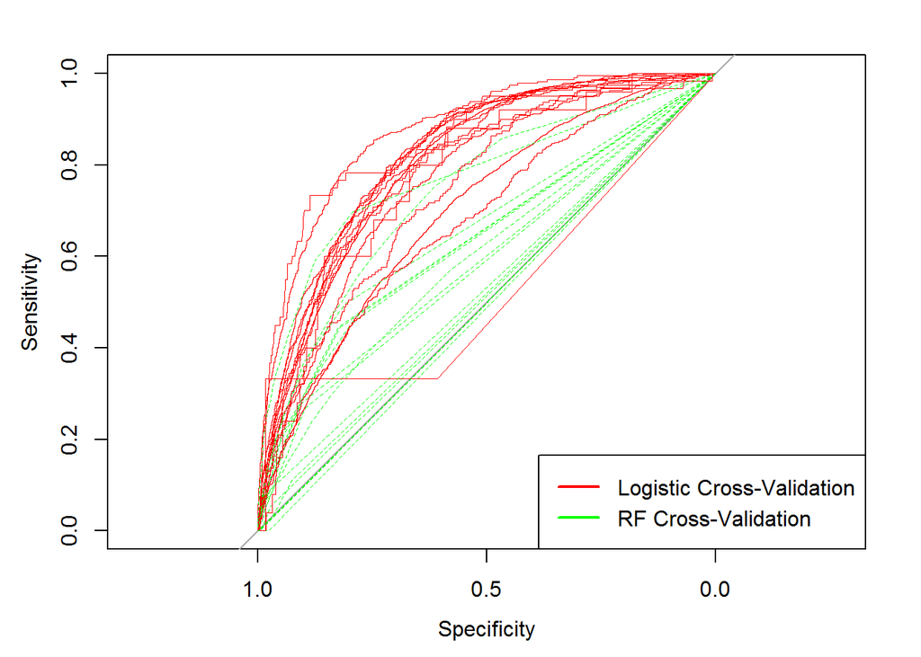

```r
#Plot ROCs
par(mfrow=c(1, 1))
i=1
plot.roc(obs.y.logit10[[i]], pred.y.logit10[[i]],  lwd = 0.7, lty=1, ci = TRUE, col = "red") #CV of svm
plot.roc(obs.y.rf10[[i]], pred.y.rf10[[i]],  lwd = 0.7, lty=2, ci = TRUE, col = "green", add = TRUE) #CV of rf
legend("bottomright", legend = c("Logistic Cross-Validation", "RF Cross-Validation"), col = c("red", "green"), lwd = 2, lty = c(1,1,2,1))
for (i in c(2:16)){
  plot.roc(obs.y.logit10[[i]], pred.y.logit10[[i]], lwd = 0.7, ci = TRUE, lty=1, col = "red", add=TRUE) #CV of svm
  plot.roc(obs.y.rf10[[i]], pred.y.rf10[[i]], lwd = 0.7, ci = TRUE, lty=2, col = "green", add = TRUE) #CV of rf
}
```

> Area Under the Curve (AUC) of the logistic regression for all the 16 full models are larger than their corresponding ones from the Random Forest models.

## 6.3., Reduced vs. Full Model Predictions

If only top 10 variables/catigories of variables are used, the prediction models can be applied for low-cost surveys. This section compares the similarity of full and top 10 variable logistic models.

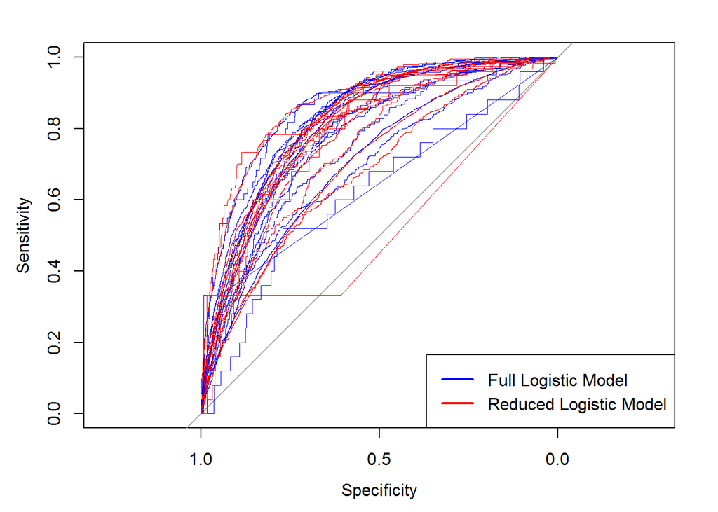

```r
i=1
plot.roc(obs.y.logit[[i]], pred.y.logit[[i]],  lwd = 0.7, lty=1, ci = TRUE, col = "blue") #CV of svm
plot.roc(obs.y.logit10[[i]], pred.y.logit10[[i]],  lwd = 0.7, lty=1, ci = TRUE, col = "red", add=TRUE) #CV of svm
legend("bottomright", legend = c("Full Logistic Model", "Reduced Logistic Model"), col = c("blue", "red"), lwd = 2, lty = c(1,1,2,1))
for (i in c(2:16)){
plot.roc(obs.y.logit[[i]], pred.y.logit[[i]], lwd = 0.7,ci = TRUE, lty=1, col = "blue", add=TRUE) #CV of svm
plot.roc(obs.y.logit10[[i]], pred.y.logit10[[i]], lwd = 0.7,ci = TRUE, lty=1, col = "red", add = TRUE) #CV of rf
}
```

```r
allauc <- cbind(aucdt, aucdt10)
names(allauc)[] <- c("Logistic_AUC", "RF_AUC", "Top10_Logistic_AUC", "Top10_RF_AUC")
allauc[, c(1,3)]
```

```
##    Logistic_AUC Top10_Logistic_AUC
## 1     0.7635645          0.7620680
## 2     0.8001406          0.8066872
## 3     0.8071521          0.8040986
## 4     0.7027323          0.6973408
## 5     0.8306800          0.8240976
## 6     0.8238273          0.8196612
## 7     0.8389730          0.8268374
## 8     0.8428873          0.8312352
## 9     0.8192221          0.8092856
## 10    0.7708274          0.7852043
## 11    0.8434906          0.8496881
## 12    0.8626201          0.8660025
## 13    0.7465415          0.7460788
## 14    0.6220787          0.7742033
## 15    0.6456473          0.5299770
## 16    0.6876770          0.6757487
```

> The prediction qualities are similar when measured by AUC values of the 2 groups of models. Estimtations of alcohol_drug abuse model with both full and top 10 variables are not converged. If ignore the unconverged results for model 15, the reduced models are as good as full model in prediction.

# 7. Discussion about Adding Parent Health as a Predictor

In the previous section the parents diseases have shown strong correlations with adults diseases. But the estimations performed with the code below cannot find many converged coefficients. The reason is the numbers of adults who have parents information are too small to contain reasonable numbers of cases for diseases. Thus, this part of the unconverged results was not reported.

```r
  cef <- NA
  sigName =NA
  dstName=NA
  sigcef <- NA
  pval <- NA
  ncomplete <- rep(NA , 16)
tryfunc <- function(){
  dim(hlth_par)
  dis_Names <- c("Vision","Hearing", "Arthritis", "Back_neck", "Heart",
                "Stroke", "Hypertension", "Diabetes", "Lung_breath", "Cancer",
                "Mental", "Weight", "Circulation", "Benign_tumor", "Alcohol_drug",
                "Chronic_liver")
  # reset the XX incase order change
  # age, BMI are numeric, others are factors

  XX <- hlth_par %>%
    select(age, sex, race,  smk, alc, sleep, activ,
            fm_size, marriage, par_stat, BMI, REGION ) ##HHX, FMX, FPX,age_smk,
  # reset the YY incase order change
  YY <- hlth_par %>%
    select(dis1, dis2, dis3, dis4, dis7,
           dis8, dis9, dis10, dis11, dis12,
           dis14, dis18, dis21, dis28, dis29,
           dis99)
  mY <- hlth_par %>%
    select(mdis1, mdis2, mdis3, mdis4, mdis7,
           mdis8, mdis9, mdis10, mdis11, mdis12,
           mdis14, mdis18, mdis21, mdis28, mdis29)
  dY <- hlth_par %>%
    select(ddis1, ddis2, ddis3, ddis4, ddis7,
           ddis8, ddis9, ddis10, ddis11, ddis12,
           ddis14, ddis18, ddis21, ddis28, ddis29)
  i=2
  for (i in 1:15) {

    Y=YY[,i]
    mom=mY[, i]
    dad=dY[, i]
    YXX <- data.frame(Y, XX, mom, dad)
    YXX <- YXX[complete.cases(YXX), ]
    #dim(data.frame(Y, XX))
    dim(YXX)
    Xmat <- data.frame(model.matrix(~., data = YXX[, c(2:ncol(YXX))] ))
    dt <-  data.frame(y=YXX[,"Y"], Xmat)
    dt.glm <- glm( y ~ . , data =dt, family = binomial(logit))
    s <- summary(dt.glm)$coefficients[,4]
    names(s)[substr(names(s), 1, 3)=="mom"] <- "mom"
    names(s)[substr(names(s), 1, 3)=="dad"] <- "dad"
    c <- summary(dt.glm)$coefficients[s < 0.05, "Estimate"]
    names(c)[substr(names(c), 1, 3)=="mom"] <- "mom"
    names(c)[substr(names(c), 1, 3)=="dad"] <- "dad"
    nam <- names(c)[2:length(c)]
    sigName[i] <- list(nam)   #significant var names
    sigcef[i] <- list(c)      #significant coefficients
    cef[i] <-  list(summary(dt.glm)$coefficients[, "Estimate"]) ## all estimate
    pval[i] <- list(s)
    names(cef[[i]])[substr(names(cef[[i]]), 1, 3) == "mom"] <- "mom"
    names(cef[[i]])[substr(names(cef[[i]]), 1, 3) == "dad"] <- "dad"
    ncomplete[i] <- nrow(YXX)
    }
# special case, there are no mom dad for liver diseases
for (i in 16) {
  Y=YY[,i]
  YXX <- data.frame(Y, XX)
  YXX <- YXX[complete.cases(YXX), ]
  #dim(data.frame(Y, XX))
  dim(YXX)
  Xmat <- data.frame(model.matrix(~., data = YXX[, c(2:ncol(YXX))] ))
  dt <-  data.frame(y=YXX[, "Y"], Xmat)
  dt.glm <- glm( y ~ . , data =dt, family = binomial(logit))
  s <- summary(dt.glm)$coefficients[, 4]
  c <- summary(dt.glm)$coefficients[s<0.05, "Estimate"]
  nam <- names(c)[2:length(c)]
  sigName[i] <- list(nam)   #significant var names
  sigcef[i] <- list(c)      #significant coefficients
  cef[i] <-  list(summary(dt.glm)$coefficients[, "Estimate"]) ## all estimate
  pval[i] <- list(s)
  ncomplete[i] <- nrow(YXX)

 }
 return(pval)
}
########################################################################################
# function created based on https://stackoverflow.com/questions/17999920/merge-vectors-of-a-list-using-row-names-in-r
comlstVect <- function (x){
  Rows <- unique(unlist(lapply(x, names)))

  ## Create a matrix of NA values
  ##   with appropriate dimensions and dimnames
  myMat <- matrix(NA, nrow = length(Rows), ncol = length(x),
                  dimnames = list(Rows, sapply(x, colnames)))
  ## Use your `for` loop to fill it in
  ##   with the appropriate values from your list
  for (i in seq_along(x)) {
    myMat[names(x[[i]]), i] <- x[[i]]
  }
  return(myMat)
}
# x <- tryfunc()
# pval <- comlstVect(x)
```

> The last chunk of R code is inactivated because most of the estimations are not converged. if readers want to check the results, please decomment the last several commented lines of commands such as “x = tryfunc()”, and “pval <- comlstVect(x)”.

# 8. Rare Events and Power of Predictions

Unfortunately, we have unbalanced data, and most diseases occure rarely in the population. Thus the true negative in the confusion table is large. This is a situation when sensitivity is large, precision is small. Such a situatioin implies that if the prediction rule of the logistic models capture most of the diseases, there would be a larger number of false positive predictions even when the rate of error is small and specificity is large. In this section, F-score is constructed as the harmonic mean of sensitivity and precision for a sequence of prediciton rules determined by predicted probability. The best prediction rule corresponding to the maximum F-score for each model is found and reported in this section.

```r
# reduced model predicted probability for each aldults
# pred.y.logit10 <- readRDS("/home/Nianfu/pred_y_logit10.rds")
# obs.y.logit10 <- readRDS("/home/Nianfu/obs_y_logit10.rds")
# Diseases data
YY <- hlth_par %>%
    select(dis1, dis2, dis3, dis4, dis7,
           dis8, dis9, dis10, dis11, dis12,
           dis14, dis18, dis21, dis28, dis29,
           dis99)
#Binary matrix
Ymat <- data.frame(model.matrix(~., data = YY ))
#rate of diseases/cases
case <- sapply(Ymat, function(x) sum(x, na.rm = TRUE))
all <- sapply(Ymat, function(x) sum(!is.na(x)))
Case.ratio <-case/all
r <- data.frame(case[-1], round(Case.ratio[-1],3))
rownames(r) <- dis_Names
colnames(r) <- c("cases","rate_of-occurance")
r
```

```
##               cases rate_of-occurance
## Vision          418             0.017
## Hearing         265             0.011
## Arthritis      3752             0.150
## Back_neck      3002             0.120
## Heart           577             0.023
## Stroke          249             0.010
## Hypertension    518             0.021
## Diabetes        495             0.020
## Lung_breath     676             0.027
## Cancer          206             0.008
## Mental           61             0.002
## Weight          516             0.021
## Circulation     207             0.008
## Benign_tumor     27             0.001
## Alcohol_drug      3             0.000
## Chronic_liver   422             0.017
```

```r
taul<- r
```

> Fourteen out of 16 diseases have rates of occurence less than 3%.

```r
#confusion matrix
conf <- pred <- pred.y.logit10
maxl <- matrix(0, nrow = 16, ncol = 7)
for (f in seq(from  =0, to=1, by = 0.01)){
  # TRUE = casse or yes disease
  pred <- lapply(pred.y.logit10, function(x) {x>f})

  for (i in 1:16){
    t <- table(obs.y.logit10[[i]], pred[[i]])
    if (nrow(t) == 2 & ncol(t) == 2) {
      sensitivity <- t[2, 2]/(t[1,2] + t[2, 2])
      specificity <- t[1, 1]/(t[1,1] + t[2, 1])
      precision <- t[2, 2]/(t[2,1] + t[2, 2])
      Fscore <- 2*sensitivity*precision/(sensitivity+precision)

      if(Fscore>maxl[i, 7] & !is.na(Fscore)) {
        maxF=Fscore
        maxl[i, ] <- c(i, f, round(sensitivity, 2), round(specificity, 2), round(precision, 2), round(Fscore, 2), round(maxF, 4))
      }
    }
  }
}
Fscor <- data.frame(dis_Names, maxl)
names(Fscor) <- c("","","pred.pr", "sensitivity","specificity","precision","Max F score", "max F")
Fscor
```

```
##                     pred.pr sensitivity specificity precision Max F score  max F
## 1         Vision  1    0.06        0.07        0.99      0.16        0.10 0.1012
## 2        Hearing  2    0.04        0.06        0.99      0.30        0.10 0.1017
## 3      Arthritis  3    0.20        0.34        0.93      0.66        0.45 0.4482
## 4      Back_neck  4    0.15        0.22        0.92      0.54        0.31 0.3132
## 5          Heart  5    0.08        0.12        0.98      0.34        0.18 0.1756
## 6         Stroke  6    0.03        0.04        0.99      0.36        0.08 0.0772
## 7   Hypertension  7    0.07        0.11        0.99      0.34        0.17 0.1705
## 8       Diabetes  8    0.09        0.13        0.98      0.25        0.17 0.1733
## 9    Lung_breath  9    0.10        0.14        0.98      0.27        0.18 0.1804
## 10        Cancer 10    0.02        0.03        0.99      0.43        0.06 0.0567
## 11        Mental 11    0.04        0.04        1.00      0.20        0.07 0.0729
## 12        Weight 12    0.15        0.27        0.98      0.25        0.26 0.2625
## 13   Circulation 13    0.03        0.05        0.99      0.17        0.07 0.0734
## 14  Benign_tumor  0    0.00        0.00        0.00      0.00        0.00 0.0000
## 15  Alcohol_drug  0    0.00        0.00        0.00      0.00        0.00 0.0000
## 16 Chronic_liver 16    0.04        0.05        0.99      0.18        0.08 0.0822
```

```r
#clearn memory
rm( "dt.glm", "hlth_par", "obs.y.logit", "obs.outputs.rf",  "obs.y.logit10", "obs.y.rf", "obs.y.rf10", "pred.y.logit", "pred.outputs.rf", "pred.y.logit", "pred.y.logit10", "pred.y.rf", "pred.y.rf10","r1","r2")
#"dt.lg", "dt0", "fX","m.data", "m.out","ps","dtxx", "obs.y.logit","rf.pred.curr"
```

> The best F-score for these models are less than 0.5. About half of the models have only F-scores equal to or less than 0.1.

# 9. Discussion of Rare Event Models

The low rates of diseases in the general US population imply the dificulty of prediction with such unbalanced data. An alternative is to estimate Rare Event Models which use only the cases and selected proportion of controls from the original survey data. The estimates are adjusted for such data selection. The method used for such models is called Rare Event Logistic Model.

## 9.1. Rare Event Full Models

Five controls are randomly selected for each of the cases. R package “Zelig” can estimate rare event logistic models with the selected records. Variables/categories of variables that are significantly correlated to diseases are identified with the rare event logistic model estimation.

```r
# install.packages("MatchIt")
#library("MatchIt")
# install.packages('Zelig')
library("Zelig")
library(dplyr)
## region is excluded
XX <- hlth %>%
  select(age, sex, race,  smk, alc, sleep, activ,
          fm_size, marriage, par_stat, BMI) ##HHX, FMX, FPX,age_smk, region
# reset the YY incase order change
YY <- hlth %>%
  select(dis1, dis2, dis3, dis4, dis7,
         dis8, dis9, dis10, dis11, dis12,
         dis14, dis18, dis21, dis28, dis29,
         dis99)
j=1
m=5
cef <- NA
sigName = NA
dstName = NA
sigcef <- NA
pval <- NA
for (j in c(1:10,13, 16)) {
  # j is the jth diseases such as dis1, dis2,...dis29, dis99
  Yj=YY[,j]
  Y=ifelse(Yj == levels(Yj)[1], 0, 1)
  YXX <- data.frame(Y, XX)
  YXX <- YXX[complete.cases(YXX), ]
  Xmat <- data.frame(model.matrix(~., data = YXX[, c(2:ncol(YXX))]))
  # reduced 10 variables
  nam <- colnames(Xmat)[-1]
  fX <- Xmat[, -1]
  YX <- data.frame(YXX$Y, fX)
  Xmat <- data.frame(model.matrix(~., data = YX[, c(2:ncol(YX))]))  #exclude y
  dt0 <-  data.frame(y=YXX[,"Y"],Xmat[,-1])

  # model formula
  formulaX <- as.formula(paste("y ~", nam[1], "+", nam[2], "+", nam[3], "+", nam[4], "+", nam[5],"+",
                               nam[6], "+", nam[7], "+", nam[8], "+", nam[9],"+", nam[10], "+",
                               nam[11], "+", nam[12], "+", nam[13], "+",nam[14], "+", nam[15], "+",
                               nam[16], "+", nam[17], "+", nam[18], "+",nam[19], "+", nam[20], "+",
                               nam[21], "+", nam[22], "+", nam[23], "+",nam[24], "+", nam[25], "+",
                               nam[26], "+", nam[27], "+", nam[28]))
  # number controls needed, m is the number controls for each case
  nmatch <- sum(dt0$y)*m
  #Id the controls
  mr <- sample(rownames(dt0[dt0$y==0,]), size=nmatch, replace=FALSE)
  # select controls
  dtm <- dt0[mr,]
  # form a new data, m controls for each case
  dt <- as.data.frame(rbind(dt0[dt0$y==1,],dtm))
  # Rare event logistic estimation
  dt.zlig  <- zelig(y ~ .,  data =dt, model = "relogit", tau = taul[j,2], cite = FALSE)
  # coefficients
  b <- coefficients(dt.zlig)
  cef[j] = list(b)
  #p-values
  pval[j] <- list(get_pvalue(dt.zlig))
}
cefTab <- as.data.frame(cef[c(1:10, 13,16)])
pvalTab <- as.data.frame(pval[c(1:10, 13, 16)])
sig <- as.data.frame(pval[c(1:10, 13, 16)]) < 0.05
sig=ifelse(sig == 0, NA, sig)
sigTab <- cefTab*sig
names(sigTab) = names(YY[c(1:10, 13, 16)])
sigTabf <- round(sigTab,2)
#significant coefficients only
print(sigTabf)
```

```
##                      dis1  dis2  dis3  dis4  dis7  dis8  dis9 dis10 dis11 dis12 dis21 dis99
## (Intercept)         -6.80 -9.73 -7.58 -4.14 -7.69 -7.91 -9.61 -9.98 -7.86 -6.71 -9.63 -4.83
## age                  0.04  0.06  0.06  0.02  0.05  0.05  0.05  0.05  0.04  0.03  0.04  0.01
## sexfemale              NA -0.50  0.53  0.14 -0.47    NA -0.28 -0.59    NA    NA    NA -0.31
## raceHispanic         0.52    NA    NA -0.15    NA    NA  0.90  1.15 -0.45    NA    NA    NA
## raceBlack            0.58    NA    NA    NA    NA  0.72  1.12  0.89    NA    NA    NA    NA
## raceAsian              NA    NA -0.63 -0.52    NA    NA  0.82  0.97 -0.89    NA    NA    NA
## raceOther            1.07    NA  0.45    NA    NA    NA  0.95  1.61    NA    NA    NA    NA
## smkFormer            0.32    NA  0.28  0.29  0.65  0.45  0.47  0.52  0.94    NA  0.43  0.35
## smkSome                NA    NA  0.55  0.68  0.63    NA  0.64    NA  1.27    NA    NA    NA
## smkDaily             0.53    NA  0.59  0.65  0.89  1.10  0.56  0.94  1.21    NA  0.78  0.49
## alcFormer              NA    NA    NA  0.18    NA    NA    NA    NA    NA    NA    NA    NA
## alcLight            -1.10    NA    NA    NA -0.82 -0.88 -0.76 -0.98    NA    NA    NA -0.52
## alcHeavier             NA    NA    NA    NA -1.16 -1.79    NA -0.70    NA    NA    NA    NA
## sleep7.hrs             NA    NA    NA    NA -0.46 -0.54    NA    NA    NA    NA    NA    NA
## sleep6.hrs             NA    NA  0.29  0.38    NA    NA    NA    NA    NA    NA    NA  0.35
## sleep5.hrs             NA    NA  0.54  0.71    NA    NA  0.50  0.47  0.59    NA    NA  0.45
## sleep..4.hrs         0.86  1.02  0.95  1.13  0.79    NA  1.02  1.26  0.82  1.03  1.26  1.26
## activSome              NA -0.75    NA -0.14 -0.78 -0.79 -0.50 -0.65 -0.41 -0.80    NA -0.38
## activModerate          NA -0.53 -0.17    NA -0.78 -0.54 -0.83 -0.71 -0.53 -1.04    NA -0.43
## activStrength          NA    NA  0.23    NA -0.44    NA -0.53    NA    NA -0.87    NA    NA
## activVigorous       -0.52 -0.92 -0.44 -0.54 -1.42 -1.22 -0.93 -0.96 -1.22 -1.90 -0.73 -0.69
## fm_size2.persons       NA    NA    NA    NA    NA    NA    NA    NA    NA    NA    NA    NA
## fm_size3.4.persons     NA    NA    NA -0.21    NA    NA  0.52    NA    NA    NA    NA -0.56
## fm_size.5.persons      NA  1.75    NA    NA    NA    NA    NA    NA    NA    NA  1.07    NA
## marriageD.S.W          NA  0.56  0.14    NA  0.47  0.58  0.58  0.46  0.53    NA  0.67    NA
## marriageNever          NA    NA    NA    NA  0.45    NA  0.46    NA  0.55    NA    NA    NA
## marriagePartner        NA    NA    NA    NA    NA    NA    NA  0.57  0.50    NA    NA    NA
## par_statNo.children    NA  1.06    NA    NA    NA    NA  0.47    NA    NA  1.09    NA -0.53
## BMI                  0.02  0.02  0.06  0.03  0.04    NA  0.07  0.09  0.04    NA  0.04  0.03
```

> Included in the table above are only significant coefficents from the estimation of full rare event models with all variables. These significant coefficients can also be respresented on a heeat map.

## 9.2 Rare Event Heatmap of P-Values of Full Models

Similar to the heat map produced for the regular logistic model, a heat map for a rare event model is constructed to show the correlation of predictors and diseases. Four diseases are excluded from the heat map because of smaller number of records used in the estimation. The regressor for US regions is excluded because the Zelig package does not produce coefficient for it in some of the models.

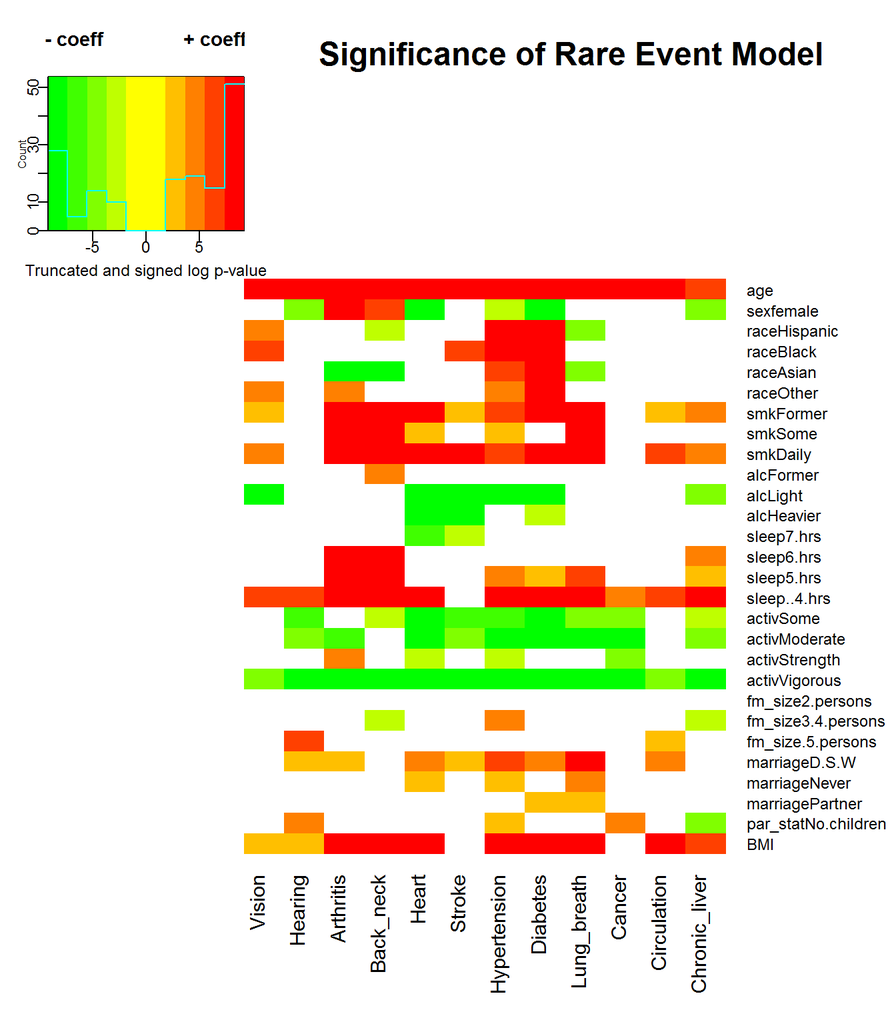

```r
library(gplots)
HMsign <- cefTab
HMsign[cefTab>0] = 1
HMsign[cefTab<0] = -1
# manage small p values
ps <- log(pvalTab)
ps[pvalTab>0.05] = NaN
pmat <- ps*HMsign*(-1)
X <- as.matrix(pmat[-1,])
Z <- X
Z[X > -log(0.0001)] = -log(0.0001)
Z[X <= log(0.0001)] = log(0.0001)
colnames(Z) <- dis_Names[c(1:10, 13, 16)]
#heatmap(X, Rowv = NA, Colv = NA, scale = "column",
#        main = "heatmap(*, NA, NA) ~= image(t(X))")
heatmap.2(Z, col=colorpanel(10, "green", "yellow", "red"),  Rowv = FALSE, Colv = FALSE,  na.color = "white",
          margin = c(8,8), trace = "none",
          main = "                    Significance of Rare Event Model",

          dendrogram = "none", key.xlab="Truncated and signed log p-value",
          key.par = list(mgp=c(1.2,0.3,0), mar=c(2.5,2.5,4,0)), key.title = "- coeff               + coeff")
```

## 9.3 Prediction with Rare Event Logistic Model

### 9.3.1 Prediction of Case-Control Samples, Top 10 Variable Rare Event Logistic Model

The top 10 most significant variables from section 9.2 are selected for the predictions with rare even model. ROC and AUC are produced to assess the quality of prediction

```r
# install.packages("MatchIt")
library("MatchIt")
#install.packages('Zelig')
library("Zelig")
# taul is from above chunk "Ch8" r
j = 1
m = 5
pred.zelig <- NA
obs.zelig <- NA
## only 1:10, 13, 16 diseases converge
for (j in c(1:12) ){
  # j is the jth diseases such as dis1, dis2,...dis29, dis99
  YY0 <- YY[, c(1:10,13,16)]
  Yj=YY0[, j]
  Y=ifelse(Yj == levels(Yj)[1], 0, 1)
  YXX <- data.frame(Y, XX)
  YXX <- YXX[complete.cases(YXX), ]
  Xmat <- data.frame(model.matrix(~., data = YXX[, c(2:ncol(YXX))]))
  # reduced 10 variables
  z <-  colnames(Xmat)[-1] # logistic coefficient from above code
  zp <- pvalTab[-1, j] #pvalue matrix from above full code
  tp10nam <- z[order(zp)][1:10] # top 10 x
  #print(paste("j=", j))
  tp10X <- Xmat[, tp10nam]
  Y10X <- data.frame(YXX$Y, tp10X)
  Xmat10 <- data.frame(model.matrix(~., data = Y10X[, c(2:ncol(Y10X))]))  #exclude y
  dt0 <-  data.frame(y=YXX[, "Y"], Xmat10[,-1])

  #propensity score matching formula
  formulaX <- as.formula(paste("y ~", tp10nam[1], "+", tp10nam[2], "+", tp10nam[3], "+", tp10nam[4], "+", tp10nam[5], "+",
                               tp10nam[6], "+", tp10nam[7], "+", tp10nam[8], "+", tp10nam[9], "+", tp10nam[10]))

  nmatch <- sum(dt0$y)*m
  mr <- sample(rownames(dt0[dt0$y == 0,]), size = nmatch, replace = FALSE)
  dtm <- dt0[mr, ]
  dtxx <- as.data.frame(rbind(dt0[dt0$y==1, ], dtm))
  #dtxx <- m.data
  n = nrow(dtxx)
  #N = nrow(dt0)
  K = 10
  set.seed(1234)
  # randomly select one of the K from N, the number of rows of data
  s = sample(1:K, size = n, replace = T) # used for label rows of data titanic for each group
  pred.outputs.logit <- vector(mode = "numeric", length = n)
  obs.outputs.logit <- vector(mode = "numeric", length = n)
  offset <- 0 # offset is a pointer used for determine where to pending results for the next loop
  i=1
  for(i in 1:K){
        train <- filter(dtxx, s != i)

        test1 <- filter(dtxx, s == i)
        #test2 <- ex.data
        test <- test1
        obs.outputs.logit[1:(n-length(s[s != i])) + offset] <- test$y

      dt.zlig  <- zelig(y ~ .,
                data =train, model = "relogit", tau = taul[i,2], cite = FALSE)
      b <- coefficients(dt.zlig)
      test.x <- as.matrix(test %>% mutate(y = 1) )
      prb <- 1/(1+exp(test.x%*%b*(-1)))
      pred.outputs.logit[1:(n-length(s[s != i])) + offset] <- prb
        offset <- offset + (n-length(s[s != i]))
     #  return(list(obs.outputs.logit, pred.outputs.logit))
    }
  pred.zelig[j] <- list(pred.outputs.logit)
  obs.zelig[j] <- list(obs.outputs.logit)
}
#confusion matrix for 1:11, 13, 16
## A combination of propensity score match and rare event logistic model
conf <- pred <- pred.zelig
f=0.2
maxl <- matrix(0, nrow = 12, ncol = 7)
for (f in seq(from = 0, to = 0.3, by = 0.001)){
  # TRUE = casse or yes disease
  pred <- lapply(pred.zelig, function(x) {x > f})

  for (i in 1:12){
    t <- table(obs.zelig[[i]], pred[[i]])
    if (nrow(t) == 2 & ncol(t) == 2) {
      sensitivity <- t[2,2]/(t[1,2]+t[2,2])
      specificity <- t[1,1]/(t[1,1]+t[2,1])
      precision <- t[2,2]/(t[2,1]+t[2,2])
      Fscore <- 2*sensitivity*precision/(sensitivity+precision)

      if(Fscore>maxl[i, 7] & !is.na(Fscore)) {
        maxF = Fscore
        maxl[i,] <- c(i, f, round(sensitivity, 2), round(specificity, 2), round(precision, 2), round(Fscore, 2), round(maxF, 4))
      }
    }
  }
}
Fscor <- data.frame(dis_Names[c(1:10, 13, 16)], maxl)
names(Fscor) <- c("", "", "pred.pr", "sensitivity", "specificity", "precision", "MaxFscore", "maxF")
Fscor
```

```
##                     pred.pr sensitivity specificity precision MaxFscore   maxF
## 1         Vision  1   0.021        0.27        0.91      0.69      0.39 0.3861
## 2        Hearing  2   0.035        0.34        0.91      0.60      0.43 0.4328
## 3      Arthritis  3   0.023        0.30        0.92      0.70      0.42 0.4187
## 4      Back_neck  4   0.012        0.21        0.91      0.81      0.33 0.3333
## 5          Heart  5   0.040        0.38        0.91      0.61      0.47 0.4654
## 6         Stroke  6   0.029        0.36        0.93      0.72      0.48 0.4816
## 7   Hypertension  7   0.034        0.36        0.91      0.64      0.46 0.4589
## 8       Diabetes  8   0.034        0.35        0.91      0.61      0.45 0.4463
## 9    Lung_breath  9   0.033        0.33        0.91      0.61      0.43 0.4290
## 10        Cancer 10   0.025        0.30        0.91      0.68      0.42 0.4182
## 11   Circulation 11   0.017        0.27        0.92      0.75      0.39 0.3926
## 12 Chronic_liver 12   0.018        0.22        0.88      0.65      0.33 0.3270
```

### 9.3.2. Prediction of All Data, Top-10 Variable Rare Event Logistic Model

In this sectiion, a test dataset used in the cross validation of the top-10 variable rare event logistic models is a combinations of the test data as in section 9.3.1. and 1/10 of the unmatched data. Thus the predictions from the 10-fold cross validation in this section represent all the population. The models are still trained with 10-folds of train data as parts of the matched subsets of data, the same as those in scetion 9.3.1. The models take a parameter tau from the combined test data. Please see variables, “top10nam”, “ex.data”,“e” and command lines with “zelig()” for the method used. when controls are selected with the nearest match, most models do not converge. Models trained with randomly matched controls perform better than nearest match.

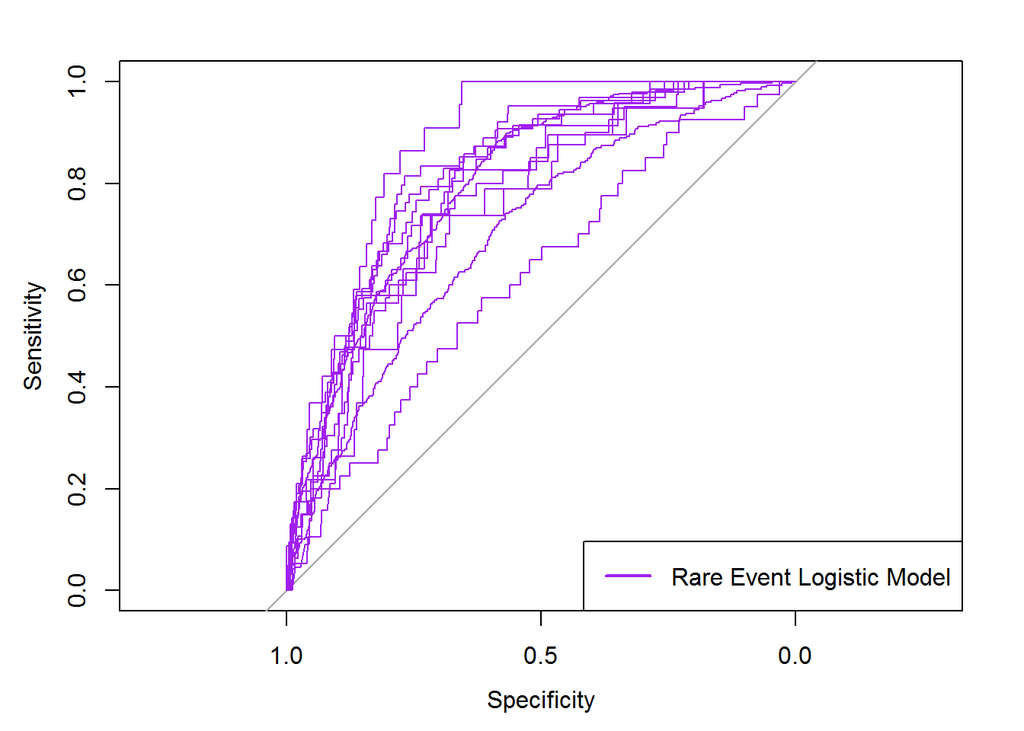

```r
# install.packages("MatchIt")
#library("MatchIt")
#install.packages('Zelig')
library("Zelig")
j=1
pred.zeligAll <- NA
obs.zeligAll <- NA
## only 1:11, 13, 16 diseases converge
for (j in c(1:12) ){
  # j is the jth diseases such as dis1, dis2,...dis29, dis99
  YY0 <- YY[,c(1:10, 13, 16)]
  Yj = YY0[,j]
  Y = ifelse(Yj == levels(Yj)[1], 0, 1)
  YXX <- data.frame(Y, XX)
  #complete records only
  YXX <- YXX[complete.cases(YXX),]
  # reconstruct egressor matrix used in section 9.1
  Xmat <- data.frame(model.matrix(~., data = YXX[, c(2:ncol(YXX))]))
  # Top 10 variables from section 9.1 for full rare event model
  z <-  rownames(cefTab)[-1] # logistic coefficient from above section 9.1 code
  zp <- pvalTab[-1, j] # pvalue matrix from above section 9.1 code
  tp10nam <- z[order(zp)][1:10] # top 10 x
  #print(paste("j=",j))

  #select the top 10 from Xmat
  tp10X <- Xmat[, tp10nam]

  # matched data for rare event regression
  Y10X <- data.frame(YXX$Y, tp10X)
  Xmat10 <- data.frame(model.matrix(~., data = Y10X[, c(2:ncol(Y10X))] ))  #exclude y

  # Top 10 variables and the jth disease data for the rare event model
  dt0 <-  data.frame(y=YXX[, "Y"],Xmat10[, -1])

  # Model formula
  formulaX <- as.formula(paste("y ~", tp10nam[1], "+", tp10nam[2], "+", tp10nam[3], "+", tp10nam[4], "+", tp10nam[5], "+",
                               tp10nam[6], "+", tp10nam[7], "+",tp10nam[8], "+", tp10nam[9], "+", tp10nam[10]))
  #Number of controls
  nmatch <- sum(dt0$y)*m
  mr <- sample(rownames(dt0[dt0$y == 0,]), size = nmatch, replace = FALSE)
  dtm <- dt0[mr,]
  #matched matrix corresponding to cases of jth disease
  dtxx <- as.data.frame(rbind(dt0[dt0$y == 1, ], dtm))
  n = nrow(dtxx)
  N = nrow(dt0)
  K = 10
  set.seed(1234)

  # randomly select one of the K from N, the number of rows of data
  s = sample(1:K, size = n, replace = T) # used for label rows for each group
  pred.outputs.logit <- vector(mode = "numeric", length = N)
  obs.outputs.logit <- vector(mode = "numeric", length = N)
  offset <- 0 # offset is a pointer used for determine where to pending results for the next loop

  #Unmatched data excluded data from sample
  ex.data <- dt0 %>% filter(!(rownames(dt0) %in% (rownames(dtxx))))
  e = sample(1:K, size = N-n, replace = T) # used for label rows of Ex.data titanic for each group
  i=1  #example for test code
  for(i in 1:K){
        train <- filter(dtxx, s != i)
        # test1= the test data from matched data
        test1 <- filter(dtxx, s == i)
        # test2=  all unmatched data for taining i
        test2 <- filter(ex.data,e==i)
        test <- rbind(test1, test2)
        obs.outputs.logit[1:(nrow(test) + offset)] <- test$y

        #tau value are the ratio of cases in the test data, this make the model flexble.
      tau_i = sum(test$y)/nrow(test)
      dt.zlig  <- zelig(y ~ .,
                data =train, model = "relogit", tau = tau_i, cite = FALSE)

      # Probability prediction for the test data, a list
      prb <- predict(dt.zlig, test, type = "response")
      pred.outputs.logit[1:(nrow(test) + offset)] <- prb[[1]]  # [[1]] to obtain the vector
        offset <- offset + nrow(test)
    }
  pred.zeligAll[j] <- list(pred.outputs.logit)
  obs.zeligAll[j] <- list(obs.outputs.logit)
}
#free some memory
Xmat <- NULL
Xmate10 <- NULL
Y10X <- Ymat <-  NULL
YX <- YXX <- NULL
YY0 <- NULL
mr <- NULL
# ROCs
library(pROC)
i = 1
plot.roc(obs.zeligAll[[i]], as.numeric(pred.zeligAll[[i]]),  lwd = 1, lty=1, ci = TRUE, col = "purple") #CV of svm
legend("bottomright", legend = c("Rare Event Logistic Model"), col = c("purple"), lwd = 2, lty = c(1))
for (i in c(2:12)){
  plot.roc(obs.zeligAll[[i]], pred.zeligAll[[i]], lwd = 1, ci = TRUE, lty=1, col = "purple", add = TRUE) #CV of rf
}
```

```r
#confusion matrix for 1:11, 13, 16
## confusion table and F score for the above model
f = 0.2 # for code test
# matrix for sensitivity, specificity, precision and maximum F-scores
maxl <- matrix(0, nrow = 12, ncol = 7)
#search for the boundary probability that has the maximum F-score
for (f in seq(from = 0, to = 0.5, by = 0.001)){
  # probability x>f = casse, yes disease
  pred <- lapply(pred.zeligAll, function(x) {x > f})

  # numbers for all diseases
  for (i in 1:12){
    t <- table(obs.zeligAll[[i]], pred[[i]])
    if (nrow(t)==2 & ncol(t)==2) {
      sensitivity <- t[2,2]/(t[1,2]+t[2,2])
      specificity <- t[1,1]/(t[1,1]+t[2,1])
      precision <- t[2,2]/(t[2,1]+t[2,2])
      Fscore <- 2*sensitivity*precision/(sensitivity+precision)
      # if an Fscore is larger than old one than change to the new one
      if(Fscore>maxl[i, 7] & !is.na(Fscore)) {
        maxF=Fscore
        maxl[i,] <- c(i, f, round(sensitivity, 2), round(specificity, 2), round(precision, 2), round(Fscore, 2), round(maxF, 4))
      }
    }
  }
}
Fscor <- data.frame(dis_Names[c(1:10,13,16)], maxl[,-1])
names(Fscor) <- c("disease", "pred.pr", "sensitivity", "specificity", "precision", "MaxFscore", "maxF")
Fscor
```

```
##          disease pred.pr sensitivity specificity precision MaxFscore   maxF
## 1         Vision   0.049        0.06        0.99      0.22      0.10 0.1008
## 2        Hearing   0.100        0.51        0.99      0.09      0.15 0.1487
## 3      Arthritis   0.237        0.36        0.92      0.58      0.44 0.4439
## 4      Back_neck   0.152        0.22        0.92      0.50      0.31 0.3057
## 5          Heart   0.111        0.16        0.98      0.26      0.20 0.1996
## 6         Stroke   0.026        0.05        0.99      0.50      0.09 0.0865
## 7   Hypertension   0.049        0.08        0.99      0.47      0.14 0.1407
## 8       Diabetes   0.125        0.18        0.98      0.17      0.18 0.1758
## 9    Lung_breath   0.096        0.15        0.98      0.30      0.20 0.2016
## 10        Cancer   0.056        0.06        0.99      0.05      0.05 0.0542
## 11   Circulation   0.033        0.07        0.99      0.21      0.11 0.1058
## 12 Chronic_liver   0.068        0.17        0.98      0.12      0.14 0.1435
```

# 10. Conclusion

The project has tabled, plotted, mapped and modeled variations of diseases and covariates of interviewed U.S. adults. Logistic models were estimated to quantitively capture these relations. The results are displayed on heatmaps or summarized in tables. The model estimation results are similar to the exploratory analyses. Major conclusions include 1. Smoking is a negative factor for health and strongly correlated with most types of diseases; 2. Physical activities are positive for health and negatively correlated with most diseases; 3. 7 hours of sleep is positively correlated to health, and less sleep is definitely positively correlated with many diseases; 4. Interestingly, drinking has a mixed correlation with health. While former alcohol users may be positively related to diseases, existing alcohol users are relatively healthier than abstainers; 5. Females, compared to males are less likely to have chronic diseases; 6. There are some regional differences among drinking, smoking, and selective diseases; 7. Prediction models have high values of AUC, but the F scores for the prediction models are very low for most of the diseases because of the rareness of the diseases, or the imbalanced data. Thus, the prediction models may predict too many false cases or not catch true cases. However, for a deadly disease, a positive prediction with a low precision can be considered as an alarm . Further medical examination should be performed. 8. Rare event models cannot predict disease risks better than logistic models.

# 11. Future Improvement Possible

Although plots show that adults’ diseases share some similarities with their parents, only 754 adults in the sample have parents information, which is not big enough for modeling the correlation between diseases of adults and their parents.

The models are estimated based on existing cases and predictors without any scientific knowledge of causality. Thus the models do not reflect causality between predictors and disease. The significant predictors are only potential candidates of causes. They may also be the results of lifestyle changes because of the awareness of risk of diseases. Although these models could predict known diseases well, they may not perform as well for predictions of risks of unknown cases as they do for known diseases.

Propensity score matching methods could be combined with rare event logistic estimation and may produce consistent estimate with a relatively smaller number of matched controls.

# 12. Aknowledgement

I would like to give special thanks to Dr. Blanca Himes, at the Institute of Biomedical Informatics of University of Pennsylvania. R methods and code are mostly based on the practicums of her Data Science for Biomedical Informatics class. This project also received help from Dr. Stephen Kawut, Dr. Rui Feng, and Biostatistician Leigh Cressman at the Center for Clinical Epidermiology and Biostatistics of the Perelman School of Medicine, University of Pennsylvania.